# bootstrap-smoothing

Junting Ren

4/6/2019

# Reading and cleaning the data

```r
down_dat = read_csv("Down.csv") %>% select(-MouseID) %>% mutate(Class = as.factor(Class)) %>%
  na.omit() #getting rid of nas since glmnet cannot handle missing data
y_full = as.matrix(ifelse(down_dat$Class == "Control",0,1))
x_full = as.matrix(down_dat %>% select(-Class))
set.seed(1001)
#Geting the trained dataset
train_index = sample(1:nrow(x_full), ceiling(nrow(x_full) * 0.9))
y_train = y_full[train_index]
x_train = x_full[train_index,]
#getting the test dataset
y_test = y_full[-train_index]
x_test = x_full[-train_index,]
```

# 1.Apply the logistic-LASSO algorihtm your group developped in Project 2 to select features for predicting Down syndrome.

## Finding our lambda sequence

According to Regularization Paths for Generalized Linear Models via Coordinate Descent, $\lambda_{max}$ is the smallest $\lambda$ where $beta$ are 0. Our strategy is to select a minimum value $\lambda_{min} = \epsilon \lambda_{max}$, and construct a sequence of K values of $\lambda$ decreasing from $\lambda_{max}$ to $\lambda_{min}$. Here we let $\epsilon = 0.001$ and $K = 10$.

```r
#Using the built in function to get the max lambda
model_glmnet = cv.glmnet(x_train, y_train, family = "binomial")
#Getting our own lambda sequence
lambda_seq = seq(max(model_glmnet$lambda), max(model_glmnet$lambda)*0.001, length.out = 10)
```

## Fitting and predicting using our model and built in lasso regression function

```r
#Our model
start = Sys.time()
log_lasso = optimize(as.data.frame(x_train),y_train, lambda_seq, rep(0.01, 77))
```

```
## [1] "Iteration: 1 done"
## [1] "Iteration: 2 done"
## [1] "Iteration: 3 done"
## [1] "Iteration: 4 done"
## [1] "Iteration: 5 done"
## [1] "Iteration: 6 done"
## [1] "Iteration: 7 done"
## [1] "Iteration: 8 done"
## [1] "Iteration: 9 done"
## [1] "Iteration: 10 done"
```

```r
our_model = log_lasso$finalModel
y_predict_our_model = predict(our_model,x_test)
y_response_our_model = as.numeric(y_predict_our_model > 0.5)
end = Sys.time()
#reuslts
accuracy_our_model = mean(y_response_our_model == y_test)
mse_our_model = mean((y_predict_our_model - y_test)^2)
time_our_model = end - start
lambda_our_model = log_lasso$lambda.min
#Compare with the built in lasso
start = Sys.time()
lasso_glmnet_cv = cv.glmnet(x_train, y_train, alpha = 1, family = "binomial", lambda = lambda_seq)
y_response_glmnet = predict.cv.glmnet(lasso_glmnet_cv, newx = x_test, type = "response", s = "lambda.min")
end = Sys.time()
#results
accuracy_glmnet = mean((y_response_glmnet>0.5) == y_test)
mse_glmnet = mean((y_response_glmnet - y_test)^2)
time_glmnet = end - start
lambda_glmnet = lasso_glmnet_cv$lambda.min
```

# 2.Use the bootstrap-smoothing approach proposed in Efron (2014, JASA) to predict Down syndrome.

## Building the bootstrap-smoothing function

```r
boot_smooth <- function(x_train,y_train,x_test,y_test,lambda_seq,iterations=100){
  predictions <- foreach(m = 1:iterations,.combine = cbind, .packages = "glmnet") %dopar% {
    boot_positions <- sample(nrow(x_train), size = nrow(x_train), replace = T)
    boot_pos <- 1:nrow(x_train) %in% boot_positions
    y = y_train[boot_pos]
    x = x_train[boot_pos,]
    cv.lasso <- cv.glmnet(x, y, alpha = 1, family = "binomial", lambda = lambda_seq)
    # Fit the final model on the training data
    model <- glmnet(x, y, alpha = 1, family = "binomial",
                lambda = cv.lasso$lambda.min)
    predict(model,newx = x_test, type = "response")
  }
  apply(predictions, 1, mean) #Getting the mean
}
```

## Prediction for bootstrap-smoothing approach

```r
start = Sys.time()
y_response_boot = boot_smooth(x_train,y_train,x_test,y_test, lambda_seq = lambda_seq, iterations = 100)
end = Sys.time()
#results
accuracy_boot = mean((y_response_boot > 0.5) == y_test)
mse_boot = mean((y_response_boot - y_test)^2)
time_boot = end - start
lambda_boot = NA
```

## Results comparing the three methods

```r
#Build a result table
result_frame = data.frame(model = c("Our lasso", "Built in cv lasso", "Boot smooth mehtod"), accuracy = c(accuracy_our_model, accuracy_glmnet, accuracy_boot),
           MSE = c(mse_our_model, mse_glmnet, mse_boot), time = c(time_our_model,time_glmnet,time_boot),
           lambda_min = c(lambda_our_model, lambda_glmnet, lambda_boot))
knitr::kable(result_frame)
```

| model | accuracy | MSE | time | lambda_min |
| --- | --- | --- | --- | --- |
| Our lasso | 0.9090909 | 0.0670202 | 1686.349409 secs | 0.0002775 |
| Built in cv lasso | 0.9818182 | 0.0227654 | 1.863576 secs | 0.0002775 |
| Boot smooth mehtod | 0.9818182 | 0.0220031 | 89.608982 secs | NA |

# 3.Compare the two approaches in predicting Down syndrome, and report your findings.

## We are going to use 4-fold cross validation on the full dataset to compare the MSE and accuracy of the two approaches.

```r
# Set the index for 5 fold cross-validation
set.seed(1000)
n_folds <- 4
folds_i <- sample(rep(1:n_folds, length.out = nrow(x_full)))
result_pool = data.frame()
for (boot_n in c(50,100,200,300)) {#Number of bootstrap samples for smooth bootstraping
  cv_tmp <- matrix(NA, nrow = n_folds, ncol = 4)
  for (k in 1:n_folds) {
    #getting the train and test dataset for this fold
    test_i <- which(folds_i == k)
    x_test = x_full[test_i,]
    y_test = y_full[test_i]
    x_train = x_full[-test_i,]
    y_train = y_full[-test_i]

    #Laso
    lasso_glmnet_cv = cv.glmnet(x_train, y_train, alpha = 1, family = "binomial", lambda = lambda_seq)
    y_response_glmnet = predict.cv.glmnet(lasso_glmnet_cv, newx = x_test, type = "response", s = "lambda.min")
    #results
    accuracy_glmnet = mean((y_response_glmnet>0.5) == y_test)
    mse_glmnet = mean((y_response_glmnet - y_test)^2)

    #bootstrap smooth
    y_response_boot = boot_smooth(x_train,y_train,x_test,y_test, lambda_seq = lambda_seq, iterations = boot_n)
    #results
    accuracy_boot = mean((y_response_boot > 0.5) == y_test)
    mse_boot = mean((y_response_boot - y_test)^2)

    #Building the result dataframe
    cv_tmp[k, 1] = accuracy_glmnet
    cv_tmp[k, 2] = accuracy_boot
    cv_tmp[k, 3] = mse_glmnet
    cv_tmp[k, 4] = mse_boot
  }
  result_cv = as.data.frame(cv_tmp)
  names(result_cv) = c("accuracy_glmnet", "accuracy_boot", "mse_glmnet", "mse_boot")
  result_cv = colMeans(result_cv)
  result_df = data.frame(Model = c("Logistic-Lasso", "Bootstrap smoothing"),
                        accuracy = c(result_cv[["accuracy_glmnet"]], result_cv[["accuracy_boot"]]),
                        MSE = c(result_cv[["mse_glmnet"]], result_cv[["mse_boot"]])，
                        Boot_sample = c(1,boot_n))
  result_pool = rbind(result_pool, result_df)
  print(c("finished ", boot_n))
}
```

```
## [1] "finished " "50"
## [1] "finished " "100"
## [1] "finished " "200"
## [1] "finished " "300"
```

```r
result_pool = unique(result_pool) #Logistic-lasso results are repeated
knitr::kable(result_pool)
```

|  | Model | accuracy | MSE | Boot_sample |
| --- | --- | --- | --- | --- |
| 1 | Logistic-Lasso | 0.9800725 | 0.0154050 | 1 |
| 2 | Bootstrap smoothing | 0.9818841 | 0.0154954 | 50 |
| 4 | Bootstrap smoothing | 0.9818841 | 0.0150206 | 100 |
| 6 | Bootstrap smoothing | 0.9818841 | 0.0151486 | 200 |
| 8 | Bootstrap smoothing | 0.9818841 | 0.0147402 | 300 |

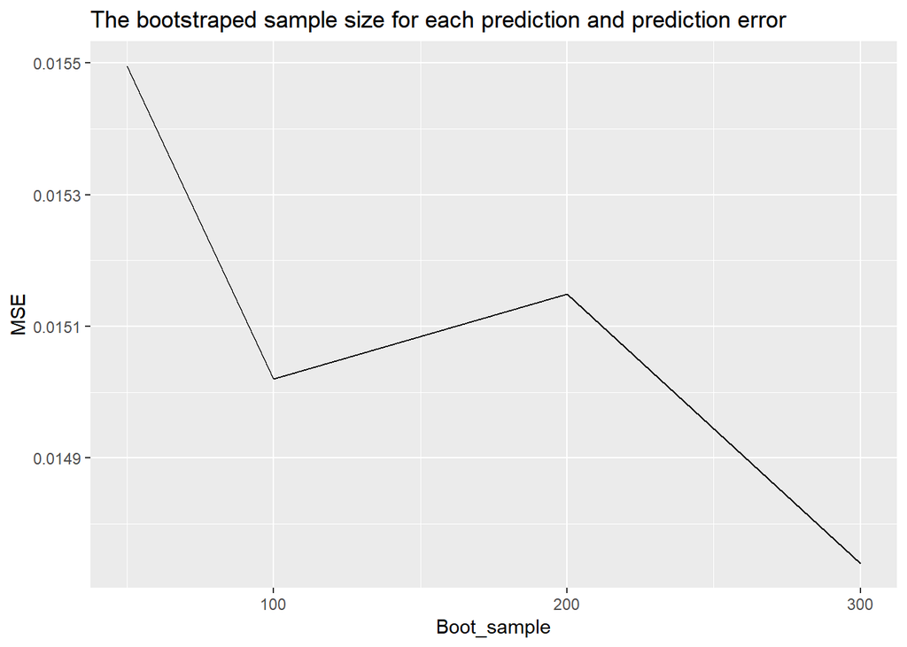

```r
result_pool %>% filter(Boot_sample > 2) %>% ggplot(aes(x = Boot_sample, y = MSE)) + geom_line() +
  labs(title = "The bootstraped sample size for each prediction and prediction error")
```

It seems they have the same accuracy.

# 4.Using bootstrap-smoothing approach to select features

## The basic algorithm:

1. Bootstrap from the full dataset
2. Cross validation and find the smallest MSE lambda model
3. Under this lambda model, store the coefficient for all variables.
4. Repeat step 1 to step 3 for $B$ times
5. Approach 1: Built an empirical confidence interval for coefficients, if the $2.5\%$ to $97.5\%$ percentile contains 0 then we drop this variable.  
   Approach 2: If any of the bootstrap coefficients contains 0, we drop this variable.  
   Approach 3: If any of the bootstrap coefficients contains non zero, we select this feature.  
   Approach 4: get the mode of the bootstrap coefficients, if the mode is non-zero, we select this feature.

```r
boot_smooth_select_feature <- function(x,y,lambda_seq,iterations=100){
  coef_boot <- foreach(m = 1:iterations,.combine = cbind, .packages = c("glmnet","tidyverse")) %dopar% {
    boot_positions <- sample(nrow(x), size = nrow(x), replace = T)
    boot_pos <- 1:nrow(x) %in% boot_positions
    y_boot = y[boot_pos]
    x_boot = x[boot_pos,]
    cv.lasso <- cv.glmnet(x_boot, y_boot, alpha = 1, family = "binomial", lambda = lambda_seq)
    # Fit the final model on the training data
    model <- glmnet(x_boot, y_boot, alpha = 1, family = "binomial",
                lambda = cv.lasso$lambda.min)
    coef(model)
  }
  approach1 = !(apply(coef_boot, 1, quantile, probs = c(0.025, 0.975)) %>% apply(.,2,is.element,0) %>% apply(.,2,any))
  approach2 = !(apply(coef_boot, 1, is.element, 0) %>% apply(.,2, any))
  approach3 = !(apply(coef_boot, 1, is.element, 0) %>% apply(.,2, all))
  approach4 = !(apply(coef_boot, 1, Mode)  %>% is.element(.,0))
  result = cbind(approach1,approach2,approach3, approach4)
  return(result)
 }
```

## Using this algorithm on the full dataset

```r
result = boot_smooth_select_feature(x_full,y_full, lambda_seq, iterations = 10)
knitr::kable(result)
```

|  | approach1 | approach2 | approach3 | approach4 |
| --- | --- | --- | --- | --- |
| (Intercept) | TRUE | TRUE | TRUE | TRUE |
| DYRK1A_N | FALSE | FALSE | FALSE | FALSE |
| ITSN1_N | TRUE | TRUE | TRUE | TRUE |
| BDNF_N | FALSE | FALSE | TRUE | FALSE |
| NR1_N | FALSE | FALSE | FALSE | FALSE |
| NR2A_N | FALSE | FALSE | TRUE | FALSE |
| pAKT_N | TRUE | TRUE | TRUE | TRUE |
| pBRAF_N | FALSE | FALSE | TRUE | FALSE |
| pCAMKII_N | TRUE | TRUE | TRUE | TRUE |
| pCREB_N | FALSE | FALSE | TRUE | FALSE |
| pELK_N | FALSE | FALSE | TRUE | FALSE |
| pERK_N | FALSE | FALSE | TRUE | FALSE |
| pJNK_N | FALSE | FALSE | FALSE | FALSE |
| PKCA_N | FALSE | FALSE | TRUE | FALSE |
| pMEK_N | FALSE | FALSE | TRUE | FALSE |
| pNR1_N | FALSE | FALSE | FALSE | FALSE |
| pNR2A_N | TRUE | TRUE | TRUE | TRUE |
| pNR2B_N | TRUE | TRUE | TRUE | TRUE |
| pPKCAB_N | FALSE | FALSE | FALSE | FALSE |
| pRSK_N | FALSE | FALSE | TRUE | FALSE |
| AKT_N | FALSE | FALSE | FALSE | FALSE |
| BRAF_N | FALSE | FALSE | TRUE | FALSE |
| CAMKII_N | TRUE | TRUE | TRUE | TRUE |
| CREB_N | FALSE | FALSE | TRUE | FALSE |
| ELK_N | FALSE | FALSE | TRUE | FALSE |
| ERK_N | TRUE | TRUE | TRUE | TRUE |
| GSK3B_N | TRUE | TRUE | TRUE | TRUE |
| JNK_N | FALSE | FALSE | FALSE | FALSE |
| MEK_N | FALSE | FALSE | TRUE | FALSE |
| TRKA_N | FALSE | FALSE | TRUE | FALSE |
| RSK_N | TRUE | FALSE | TRUE | TRUE |
| APP_N | TRUE | TRUE | TRUE | TRUE |
| Bcatenin_N | TRUE | FALSE | TRUE | FALSE |
| SOD1_N | FALSE | FALSE | FALSE | FALSE |
| MTOR_N | FALSE | FALSE | TRUE | FALSE |
| P38_N | FALSE | FALSE | TRUE | FALSE |
| pMTOR_N | FALSE | FALSE | TRUE | FALSE |
| DSCR1_N | FALSE | FALSE | TRUE | FALSE |
| AMPKA_N | FALSE | FALSE | TRUE | FALSE |
| NR2B_N | FALSE | FALSE | TRUE | FALSE |
| pNUMB_N | FALSE | FALSE | TRUE | FALSE |
| RAPTOR_N | TRUE | FALSE | TRUE | TRUE |
| TIAM1_N | FALSE | FALSE | TRUE | FALSE |
| pP70S6_N | FALSE | FALSE | TRUE | FALSE |
| NUMB_N | FALSE | FALSE | FALSE | FALSE |
| P70S6_N | FALSE | FALSE | TRUE | FALSE |
| pGSK3B_N | TRUE | FALSE | TRUE | FALSE |
| pPKCG_N | FALSE | FALSE | FALSE | FALSE |
| CDK5_N | FALSE | FALSE | TRUE | FALSE |
| S6_N | FALSE | FALSE | TRUE | FALSE |
| ADARB1_N | FALSE | FALSE | TRUE | FALSE |
| AcetylH3K9_N | FALSE | FALSE | TRUE | FALSE |
| RRP1_N | TRUE | FALSE | TRUE | TRUE |
| BAX_N | FALSE | FALSE | TRUE | FALSE |
| ARC_N | FALSE | FALSE | TRUE | FALSE |
| ERBB4_N | FALSE | FALSE | TRUE | FALSE |
| nNOS_N | FALSE | FALSE | TRUE | FALSE |
| Tau_N | TRUE | TRUE | TRUE | TRUE |
| GFAP_N | TRUE | FALSE | TRUE | FALSE |
| GluR3_N | TRUE | TRUE | TRUE | TRUE |
| GluR4_N | FALSE | FALSE | TRUE | FALSE |
| IL1B_N | TRUE | TRUE | TRUE | TRUE |
| P3525_N | FALSE | FALSE | TRUE | FALSE |
| pCASP9_N | FALSE | FALSE | FALSE | FALSE |
| PSD95_N | FALSE | FALSE | TRUE | FALSE |
| SNCA_N | TRUE | FALSE | TRUE | TRUE |
| Ubiquitin_N | TRUE | TRUE | TRUE | TRUE |
| pGSK3B_Tyr216_N | FALSE | FALSE | TRUE | FALSE |
| SHH_N | TRUE | FALSE | TRUE | FALSE |
| BAD_N | FALSE | FALSE | TRUE | FALSE |
| BCL2_N | FALSE | FALSE | TRUE | FALSE |
| pS6_N | TRUE | FALSE | TRUE | TRUE |
| pCFOS_N | FALSE | FALSE | TRUE | FALSE |
| SYP_N | TRUE | FALSE | TRUE | FALSE |
| H3AcK18_N | FALSE | FALSE | FALSE | FALSE |
| EGR1_N | FALSE | FALSE | TRUE | FALSE |
| H3MeK4_N | FALSE | FALSE | TRUE | FALSE |
| CaNA_N | TRUE | TRUE | TRUE | TRUE |